# Lab 4

Ashley Anderson & Hexiang Zhang

10/24/2019

Owner Username: ashleyna7  
Partner Username: hexzha  
Repo Name: ds202_lab4

## Loading Data: Cyclone Football

```r
library(readxl)
defense <- read_excel('cyclonesFootball2018.xlsx', sheet='Defensive')
str(defense)
```

```
## Classes 'tbl_df', 'tbl' and 'data.frame':    446 obs. of  11 variables:
##  $ Name             : chr  "Eisworth, Greg" "Eisworth, Greg" "Eisworth, Greg" "Eisworth, Greg" ...
##  $ Opponent_Opponent: chr  "Iowa" "Oklahoma" "Akron" "TCU" ...
##  $ Tackles_Solo     : chr  "3" "6" "7" "6" ...
##  $ Tackles_ASST     : chr  "3" "8" "2" "3" ...
##  $ Tackles_TFL      : chr  "0" "1.0" "1.0" "0" ...
##  $ Tackles_Sack     : chr  "0" "0" "0" "0" ...
##  $ Turnover_FF      : chr  "0" "1" "0" "0" ...
##  $ Turnover_FR      : chr  "0" "0" "0" "0" ...
##  $ Turnover_INT     : chr  "0" "0" "0" "0" ...
##  $ Pass_QBH         : chr  "0" "0" "0" "0" ...
##  $ Pass_PB          : chr  "0" "0" "3" "0" ...
```

## Part one: Cleaning data

```r
defClean <- defense
offClean <- offense
bioClean <- bio

defClean$Name <- as.factor(defClean$Name)
offClean$Name <- as.factor(offClean$Name)
bioClean$Name <- as.factor(bioClean$Name)

defClean$Opponent_Opponent <- as.factor(defClean$Opponent_Opponent)
offClean$Opponent_Opponent <- as.factor(offClean$Opponent_Opponent)
```

```r
defense_names <- c(colnames(defClean[,3:11]))
defClean[defense_names] <- sapply(defClean[defense_names],as.numeric)

offense_names <- c(colnames(offClean[,3:12]))
offClean[offense_names] <- sapply(offClean[offense_names],as.numeric)
bioClean$Weight <- as.numeric(bioClean$Weight)
```

3. Separate the `Height` column into two columns. Make sure the newly created columns are numeric. Then create one column that represents `Height` (Hint: Use a unit that works well). Drop any irrelavant columns from this process.

```r
library(tidyverse)
bioClean <- bio %>%
  separate(Height, c("Feet", "Inches")) %>%
  mutate_each_(funs(as.numeric), c("Feet", "Inches")) %>%
  group_by(Feet, Inches) %>%
  mutate(Height=(Feet*12)+Inches)
head(bioClean$Height)
```

```
## [1] 72 79 74 76 72 71
```

4. By cleaning the three data frames in R, at the end of this step you should have the following three clean data frames: `defClean`, `offClean`, and `bioClean`. Print the structures of these data frames. **Make sure your data types make sense for each variable.**

```r
str(defClean)
```

```
## Classes 'tbl_df', 'tbl' and 'data.frame':    446 obs. of  11 variables:
##  $ Name             : Factor w/ 42 levels "Akers, Landen",..: 7 7 7 7 7 7 7 7 7 7 ...
##  $ Opponent_Opponent: Factor w/ 13 levels "Akron","Baylor",..: 4 7 1 9 8 13 11 5 2 10 ...
##  $ Tackles_Solo     : num  3 6 7 6 3 5 3 7 2 9 ...
##  $ Tackles_ASST     : num  3 8 2 3 0 3 2 1 4 3 ...
##  $ Tackles_TFL      : num  0 1 1 0 1 1 0 0 0 0 ...
##  $ Tackles_Sack     : num  0 0 0 0 0 1 0 0 0 0 ...
##  $ Turnover_FF      : num  0 1 0 0 0 0 0 0 0 1 ...
##  $ Turnover_FR      : num  0 0 0 0 0 0 0 0 0 0 ...
##  $ Turnover_INT     : num  0 0 0 0 0 0 1 0 0 0 ...
##  $ Pass_QBH         : num  0 0 0 0 0 0 0 0 0 0 ...
##  $ Pass_PB          : num  0 0 3 0 0 0 0 0 0 0 ...
```

```r
str(offClean)
```

```
## Classes 'tbl_df', 'tbl' and 'data.frame':    168 obs. of  12 variables:
##  $ Name             : Factor w/ 15 levels "Akers, Landen",..: 6 6 6 6 6 6 6 6 6 6 ...
##  $ Opponent_Opponent: Factor w/ 13 levels "Akron","Baylor",..: 4 7 1 9 8 13 11 5 2 10 ...
##  $ Receiving_REC    : num  1 9 6 3 6 1 1 4 4 0 ...
##  $ Receiving_YDS    : num  31 66 39 23 37 32 4 31 39 0 ...
##  $ Receiving_TD     : num  0 0 0 0 1 1 0 0 1 0 ...
##  $ Rushing_ATT      : num  NA NA NA NA NA NA NA NA NA NA ...
##  $ Rushing_YDS      : num  NA NA NA NA NA NA NA NA NA NA ...
##  $ Rushing_TD       : num  NA NA NA NA NA NA NA NA NA NA ...
##  $ Passing_CMP-ATT  : num  NA NA NA NA NA NA NA NA NA NA ...
##  $ Passing_YDS      : num  NA NA NA NA NA NA NA NA NA NA ...
##  $ Passing_TD       : num  NA NA NA NA NA NA NA NA NA NA ...
##  $ Passing_INT      : num  NA NA NA NA NA NA NA NA NA NA ...
```

```r
str(bioClean)
```

```
## Classes 'grouped_df', 'tbl_df', 'tbl' and 'data.frame':  123 obs. of  9 variables:
##  $ Name      : chr  "Akers, Landen" "Allen, Chase" "Alt, Gerry" "Anderson, Cole" ...
##  $ Position  : chr  "Wide Receiver" "Tight End" "Offensive Line" "Tight End" ...
##  $ Feet      : num  6 6 6 6 6 5 6 6 6 6 ...
##  $ Inches    : num  0 7 2 4 0 11 0 3 2 2 ...
##  $ Weight    : chr  "192" "240" "290" "250" ...
##  $ Class     : chr  "Redshirt Sophomore" "Redshirt Sophomore" "Redshirt Freshman" "Redshirt Senior" ...
##  $ Hometown  : chr  "Cedar Rapids, Iowa" "Nixa, Mo." "Cedar Rapids, Iowa" "League City, Texas" ...
##  $ Highschool: chr  "Washington" "Nixa" "Washington" "Clear Falls" ...
##  $ Height    : num  72 79 74 76 72 71 72 75 74 74 ...
##  - attr(*, "groups")=Classes 'tbl_df', 'tbl' and 'data.frame':   13 obs. of  3 variables:
##   ..$ Feet  : num  5 5 5 5 6 6 6 6 6 6 ...
##   ..$ Inches: num  8 9 10 11 0 1 2 3 4 5 ...
##   ..$ .rows :List of 13
##   .. ..$ : int 55
##   .. ..$ : int  69 78 93 123
##   .. ..$ : int  29 46 48 66 77 91 107 114 117 121 ...
##   .. ..$ : int  6 17 18 22 34 35 42 45 54 60 ...
##   .. ..$ : int  1 5 7 25 28 32 37 43 44 47 ...
##   .. ..$ : int  13 23 26 30 33 36 40 41 70 73 ...
##   .. ..$ : int  3 9 10 12 16 64 80 85 88 90 ...
##   .. ..$ : int  8 14 19 56 61 62 86 87 94 95 ...
##   .. ..$ : int  4 11 20 21 24 49 58 63 71 72 ...
##   .. ..$ : int  31 50 52 82 109
##   .. ..$ : int  15 38 39 51 53 65 97 101 111
##   .. ..$ : int  2 59 102
##   .. ..$ : int 27
##   ..- attr(*, ".drop")= logi TRUE
```

## Part two: Tidying (A)

For the following questions, work on the cleaned data frames `defClean`, `offClean`, and `bioClean`.

1. Reformat the `defClean` data frame into a tidy format using `gather`. The type of statistic (Tackles_Solo, Tackles_ASST, etc) is added as a **new key column named `Statistic`.**

```r
defClean2 <- defClean %>%
  gather(key=Statistic, value=Value, 3:11)
```

2. Create a histogram for each defensive statistic (make sure to explore different binwidths). Use `facet_wrap` to draw all histograms in a single plot. What defensive skills are rare?

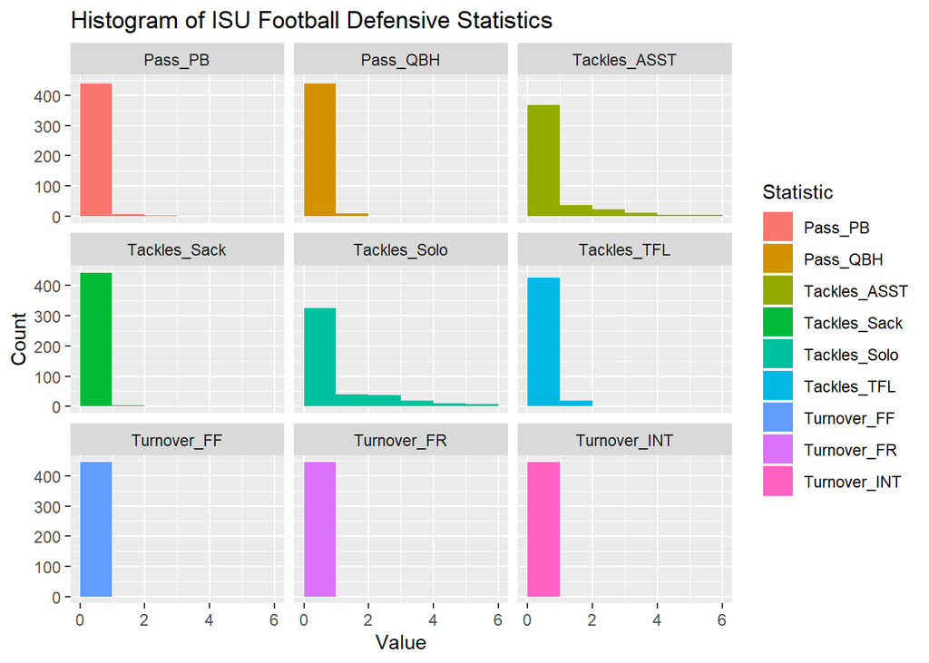

```r
ggplot(defClean2, aes(Value, fill=Statistic)) + geom_histogram(breaks=seq(0,6,by=1)) + facet_wrap(~Statistic) + labs(title="Histogram of ISU Football Defensive Statistics", x="Value", y="Count")
```

Above is a histigram of each defensive statistic facet wrapped together. The bins (value) represent how many times a statistic was recorded. Count represent number of players. We can see that Turnover_FF, Turnover_FR, and Turnover_INT are all rare as the graph does not show any other bins than than 0 bin, indicating these defensive skills rarely happen.

3. Did ISU have better defense against West Virginia or Kansas State? Answer this question by creating a scatterplot with x-axis being the number of solo tackles (by each player) against West Virginia, and y-axis being that against Kansas State. A large number of solo tackles indicates good defense.

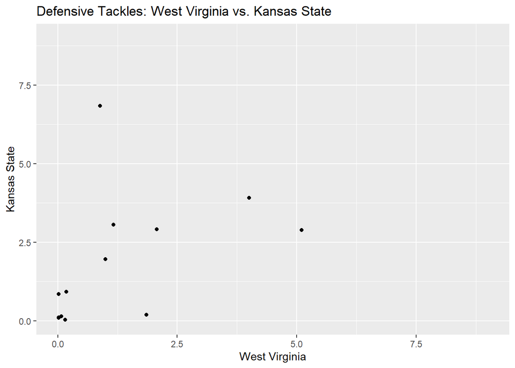

```r
defClean2 %>%
  filter(Statistic=="Tackles_Solo") %>%
  spread(key=Opponent_Opponent, value=Value) %>%
  rename(KansasState = "Kansas State", WestVirginia = "West Virginia") %>%
  drop_na(KansasState, WestVirginia) %>%
  ggplot(aes(x=WestVirginia, y=KansasState)) + geom_jitter(width = 0.2, height = 0.2) + labs(title="Defensive Tackles: West Virginia vs. Kansas State", x="West Virginia", y="Kansas State") + xlim(0,9) + ylim(0,9)
```

Above is a scatterplot of the number of solo tackles by each ISU player between West Virginia and Kansas State. From the plot, we can say that ISU has better defense against Kansas State than West Virginia.

## Part two: Tidying (B)

Now let’s turn our attention to the player biography `bioClean`.

1. Separate the `Hometown` column into two columns, namely the city and the state. Print the first few rows of these two columns. (Hint: look at the `sep=` argument of `separate`)

```r
bioClean <- bioClean %>%
  separate(Hometown, c("City", "State"), sep = ',')
head(bioClean[,7:8])
```

```
## # A tibble: 6 x 2
##   City         State
##   <chr>        <chr>
## 1 Cedar Rapids " Iowa"
## 2 Nixa         " Mo."
## 3 Cedar Rapids " Iowa"
## 4 League City  " Texas"
## 5 Naperville   " Ill."
## 6 Walnut       " Calif."
```

2. How many players are there from each state?

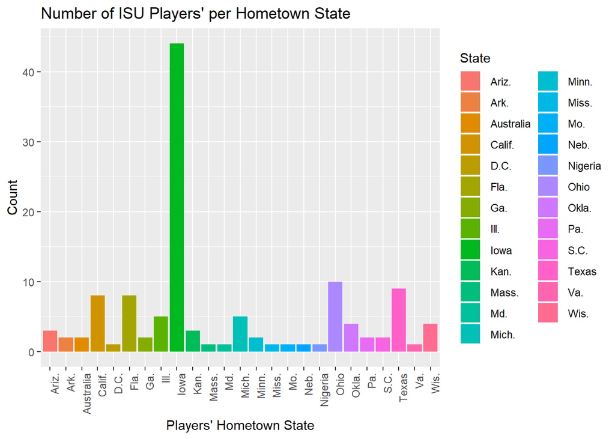

```r
perState <- bioClean %>%
  group_by(State) %>%
  tally()

ggplot(perState, aes(x=State, y=n, fill = State)) + geom_bar(stat="identity") + labs(title = "Number of ISU Players' per Hometown State") + xlab("Players' Hometown State") + ylab("Count") + theme(axis.text.x=element_text(angle=90,hjust=1))
```

Above is a bar graph of the count of ISU players per hometown state.

## Part three: Joining data frames

1. Find out where the offensive players are from by joining the offensive data and player biography data appropriately.

```r
off <- offClean %>%
  inner_join(bioClean, by=c("Name"="Name"))
```

2. Is there a relationship between the weight of a player and the receiving yards (`Receiving_YDS`)?

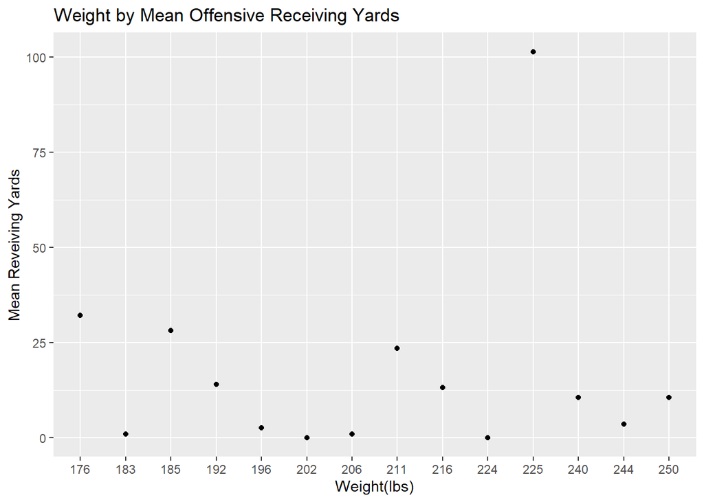

```r
off %>%
  group_by(Name) %>%
  summarize(mean_receiving_yds = mean(Receiving_YDS, na.rm = TRUE)) %>%
  mutate_at(vars(mean_receiving_yds), ~replace(., is.nan(.), 0)) %>%
  left_join(off,bioClean,by=("Name"="Name")) %>%
  ggplot(aes(x=Weight, y=mean_receiving_yds)) + geom_point() + labs(title="Weight by Mean Offensive Receiving Yards", x="Weight(lbs)", y="Mean Reveiving Yards")
```

The scatterplot above shows the weight of each offensive player versus their mean recieving yards. Looking at the plot, there does not appear to be much of a relationship between the weight of an offensive player and the average amount of receiving yards a player has.

3. Explore more. Raise a question that can be answered only by looking at two or more data frames. Then answer that question.

Do offensive or defensive players weight more?

```r
off <- offClean %>%
  inner_join(bioClean, by=c("Name"="Name"))
def <- defClean %>%
  inner_join(bioClean, by=c("Name"="Name"))
```

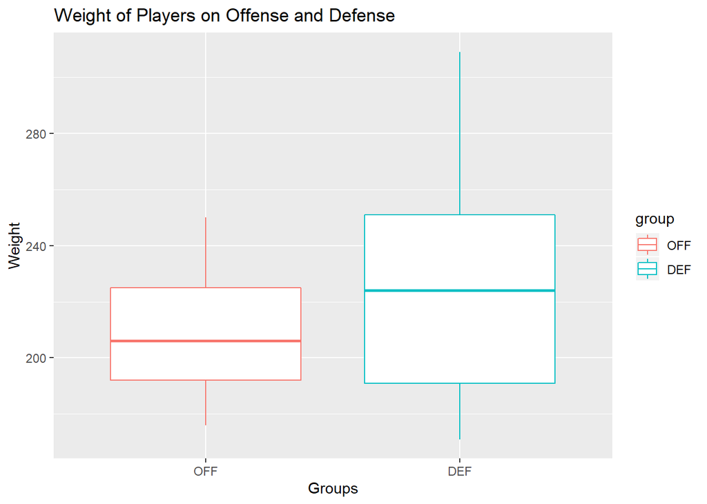

```r
a = data.frame(group = "OFF", value = off$Weight)
b = data.frame(group = "DEF", value = def$Weight)

plot.data = rbind(a, b)
plot.data$value = sapply(sapply(plot.data$value, as.character), as.numeric)

ggplot(plot.data, aes(x = group, y = value, color = group)) + xlab("Groups") +  ylab("Weight") + labs(title = "Weight of Players on Offense and Defense") + geom_boxplot()
```

The boxplot above shows a boxplot of the weight of players on offense and defense.

We can see that the average weight of defensive players is heavier than offensive players.